# Text Analysis Of Corporate Reponsibility Reports

Mark Wilcock

6 June 2017

## Introduction

The purpose is to analyse several previous annual Corporate Reponsibility Reports (CRRs) of a large bank using text mining to understand if these reflect changes in emphasis or importance of topics to the firm over the period.

I owe a debt of gratitude to the wonderful [Text Mining With R book](http://tidytextmining.com/index.html) by Julia Silge and David Robinson.

Load a list of *our* words of interest (business sentiment / topic analysis)

```r
hot_list <-  read_excel("CRR Custom Words.xlsx", sheet = "hot_words")
hot_words <-
  hot_list %>%
  gather(key = "category", value = "word") %>%
  filter(!is.na(word))

hot_words
```

```
## # A tibble: 37 x 2
##    category        word
##       <chr>       <chr>
##  1  conduct    behavior
##  2  conduct   behaviour
##  3  conduct     bribery
##  4  conduct     conduct
##  5  conduct  corruption
##  6  conduct     ethical
##  7  conduct      ethics
##  8  conduct trafficking
##  9  conduct      weapon
## 10  conduct      rights
## # ... with 27 more rows
```

Stop words are very common words of no interest in text analysis Load a few custom stop words and combine with a standard list of stop words.

```r
crr_stop_words <-
  read_excel("CRR Custom Words.xlsx", sheet = "stop_words") %>%
  select(word = stop_words) %>%
  mutate(lexicon = "CRR")

all_stop_words <- bind_rows(stop_words, crr_stop_words)

all_stop_words
```

```
## # A tibble: 1,158 x 2
##           word lexicon
##          <chr>   <chr>
##  1           a   SMART
##  2         a's   SMART
##  3        able   SMART
##  4       about   SMART
##  5       above   SMART
##  6   according   SMART
##  7 accordingly   SMART
##  8      across   SMART
##  9    actually   SMART
## 10       after   SMART
## # ... with 1,148 more rows
```

Parse the PDF CRR reports into pages of text. Split those pages into single words. Lowercase words and do some cleaning to remove some PDF artefacts Remove all stop words

```r
get_text_from_crr_pdf <- function(year, to_lower = TRUE) {
# Returns a data frame with 3 columns
# - pagenumber - of the page of the CRR report
# - year of the CRR report
# - word (all stop words removed and any other unigram that is not made of of letters)
    filename = paste0("PDFs/csg-crr-", year, "-en.pdf")

    data_frame(page = pdf_text(filename)) %>%
    mutate(
      pagenumber = row_number(),
      year = year) %>%
      unnest_tokens(word, page, to_lower = to_lower) %>%
      mutate(word = str_extract(word, "[A-Za-z']+")) %>%  # clean up of any PDF chars not removed by previous operations
      filter(!is.na(word)) %>% # previous operation may have created NAs if all chars were not letters
      anti_join(all_stop_words, by = "word")
}

useful_words <- bind_rows(
  get_text_from_crr_pdf('2016'),
  get_text_from_crr_pdf('2015'),
  get_text_from_crr_pdf('2014'),
  get_text_from_crr_pdf('2013'),
  get_text_from_crr_pdf('2012'),
  get_text_from_crr_pdf('2011'),
  get_text_from_crr_pdf('2010'))


useful_words
```

```
## # A tibble: 119,407 x 3
##    pagenumber  year      word
##         <int> <chr>     <chr>
##  1          1  2016 corporate
##  2          2  2016 corporate
##  3          2  2016 corporate
##  4          2  2016 corporate
##  5          3  2016 corporate
##  6          3  2016 corporate
##  7          3  2016 corporate
##  8          3  2016 corporate
##  9          3  2016 corporate
## 10          5  2016 corporate
## # ... with 119,397 more rows
```

Find the top 20 words across all reports

```r
top_words <- useful_words %>%
  count(word, sort = TRUE) %>%
  mutate(ranking = min_rank(desc(n))) %>%
  ungroup() %>%
  filter(ranking <= 20)

top_words
```

```
## # A tibble: 20 x 3
##              word     n ranking
##             <chr> <int>   <int>
##  1      employees  1004       1
##  2      financial   934       2
##  3       business   889       3
##  4 responsibility   873       4
##  5         global   783       5
##  6         social   654       6
##  7      corporate   638       7
##  8        clients   632       8
##  9  environmental   605       9
## 10     management   602      10
## 11          swiss   588      11
## 12    switzerland   583      12
## 13           risk   577      13
## 14       services   566      14
## 15           bank   537      15
## 16        support   511      16
## 17         energy   490      17
## 18        banking   479      18
## 19        capital   463      19
## 20 sustainability   460      20
```

And plot these as a bar chart

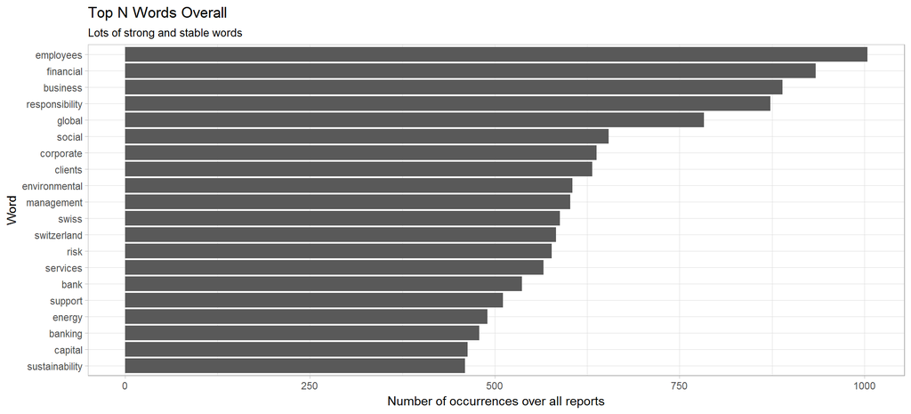

```r
ggplot(top_words, aes(x = fct_reorder(word, n), y = n)) +
  geom_bar(stat = "identity") +
  coord_flip() +
  theme_light() +
  ggtitle(label = "Top N Words Overall",
          subtitle = "Lots of strong and stable words") +
  xlab("Word") +
  ylab("Number of occurrences over all reports")
```

Look at the count of these top words by year.

```r
top_words_by_year <-
  useful_words %>%
  count(year, word, sort = TRUE) %>%
  mutate(ranking = min_rank(desc(n))) %>%
  ungroup() %>%
  semi_join(top_words, by = "word")

top_words_by_year
```

```
## # A tibble: 140 x 4
##     year      word     n ranking
##    <chr>     <chr> <int>   <int>
##  1  2011 employees   174       1
##  2  2012 employees   162       1
##  3  2013 employees   160       2
##  4  2014 employees   160       2
##  5  2015 employees   123       1
##  6  2010 employees   114       1
##  7  2016 employees   111       3
##  8  2014 financial   167       1
##  9  2013 financial   165       1
## 10  2012 financial   161       2
## # ... with 130 more rows
```

Plot these top_words_by_year.

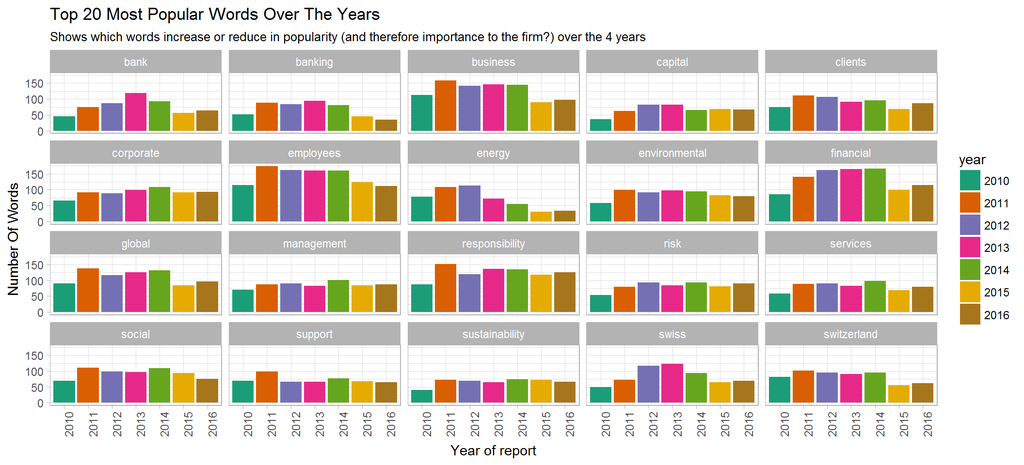

```r
year_colours <- brewer.pal(7, "Dark2")
# Plot facted bar charts showing the frequency of the most common words across the years
ggplot(top_words_by_year, aes(x = year, y = n, fill = year)) +
  geom_bar(stat = "identity") +
  facet_wrap(~word, ncol = 5) +
  ggtitle("Top 20 Most Popular Words Over The Years",
          "Shows which words increase or reduce in popularity (and therefore importance to the firm?) over the 4 years") +
  scale_y_continuous("Number Of Words") +
  scale_x_discrete("Year of report") +
  #scale_fill_tableau(palette = "tableau10medium") +
  scale_fill_manual(values = year_colours) +
  #scale_fill_economist()
#scale_fill_manual(values = c("red", "yellow", "green", "blue")) +
  theme_light() +
  theme(legend.position = "right")  +
  theme(axis.text.x = element_text(angle = 90, hjust = 1)) # year labels rorated to fit
```

## Basic Frequency Analysis

The analysis above was a bit dodgy since it dd not take into account the (slightly) different lengths of the documents. Calculate the *proportions* of each word

```r
proportions <-
  useful_words %>%
  count(year, word) %>%
  mutate(proportion = n / sum(n))  %>%
  ungroup() %>%
  select (-n) %>%
  spread(year, proportion) %>%
  left_join(hot_words, by = "word") %>%
  mutate(category = ifelse(is.na(category), 'none', category))

proportions
```

```
## # A tibble: 8,428 x 9
##         word       `2010`       `2011`       `2012`       `2013`
##        <chr>        <dbl>        <dbl>        <dbl>        <dbl>
##  1        aa 1.298280e-04           NA           NA           NA
##  2       aaa 6.491399e-05 4.776233e-05 5.129784e-05 5.490584e-05
##  3       aae           NA           NA           NA           NA
##  4  aargauer 6.491399e-05           NA           NA 5.490584e-05
##  5        ab 6.491399e-05           NA           NA           NA
##  6 abatement           NA           NA 5.129784e-05           NA
##  7       abb           NA           NA           NA 5.490584e-05
##  8     abfal           NA           NA 5.129784e-05           NA
##  9 abilities 6.491399e-05 9.552467e-05           NA           NA
## 10   ability 6.491399e-04 7.641974e-04 9.233610e-04 1.043211e-03
## # ... with 8,418 more rows, and 4 more variables: `2014` <dbl>,
## #   `2015` <dbl>, `2016` <dbl>, category <chr>
```

```r
# the proportion_comparison16 dataset  makes it possible to compare  the 2016 proportions
# against the  earlier years.
proportion_comparison16  <-
  proportions %>% gather(year, proportion, `2010`:`2015`)

proportion_comparison16
```

```
## # A tibble: 50,568 x 5
##         word       `2016` category  year   proportion
##        <chr>        <dbl>    <chr> <chr>        <dbl>
##  1        aa           NA     none  2010 1.298280e-04
##  2       aaa 7.251106e-05     none  2010 6.491399e-05
##  3       aae 7.251106e-05     none  2010           NA
##  4  aargauer 7.251106e-05     none  2010 6.491399e-05
##  5        ab           NA     none  2010 6.491399e-05
##  6 abatement           NA     none  2010           NA
##  7       abb           NA     none  2010           NA
##  8     abfal           NA     none  2010           NA
##  9 abilities           NA     none  2010 6.491399e-05
## 10   ability 1.305199e-03     none  2010 6.491399e-04
## # ... with 50,558 more rows
```

Plot 2016 frequencies against the previous years.

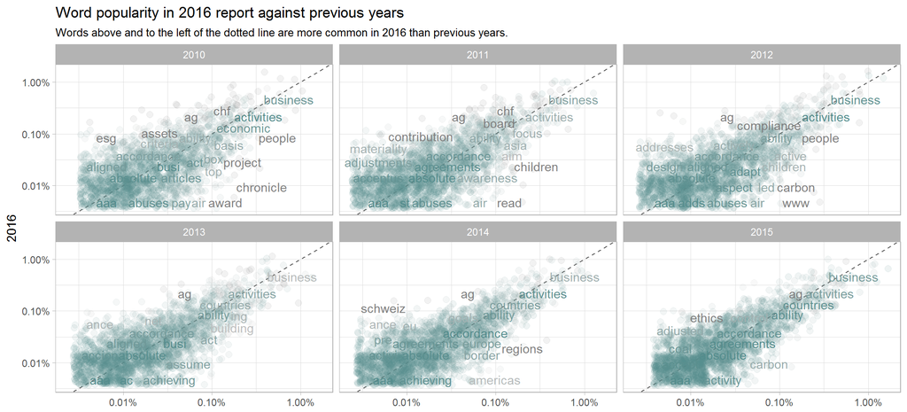

```r
ggplot(proportion_comparison16, aes(x = proportion, y = `2016`, color = abs(`2016` - proportion))) +
  geom_abline(color = "gray40", lty = 2) +
  geom_jitter(alpha = 0.1, size = 2.5, width = 0.3, height = 0.3) +
  geom_text(aes(label = word), check_overlap = TRUE, vjust = 1.5) +
  scale_x_log10(labels = percent) +
  scale_y_log10(labels = percent) +
  scale_color_gradient(limits = c(0,0.001), low = "darkslategray4", high = "gray75") +
  facet_wrap(~year, ncol = 3) +
  labs(y = "2016", x = NULL) +
  theme_light() +
  theme(legend.position = "none") +
  ggtitle(label =   "Word popularity in 2016 report against previous years",
           subtitle = "Words above and to the left of the dotted line are more common in 2016 than previous years.")
```

Focus on the hot words. Show these in different colour based on category and label these only.

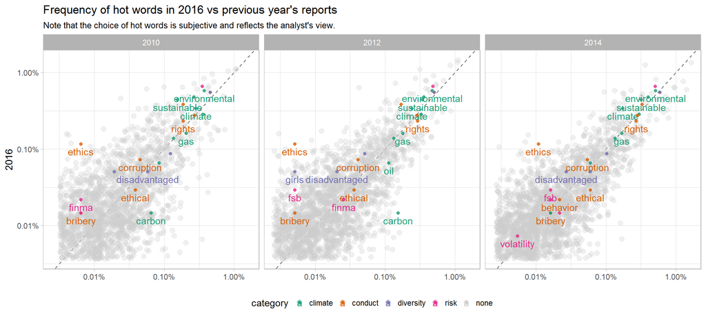

```r
comp16_short <-  proportion_comparison16 %>% filter(year %in% c("2010", "2012", "2014"))
comp16_short_cold <-  comp16_short %>%  filter(category == "none")
comp16_short_hot <-  comp16_short %>%  filter(category != "none")

p <- brewer.pal(4, "Dark2")
legend_colours <- c(climate = p[1], conduct = p[2], diversity = p[3], risk = p[4], none = "grey80")
legend_order <- c("climate", "conduct", "diversity", "risk", "none")
ggplot(comp16_short, aes(x = proportion, y = `2016`, color = category)) +
  geom_abline(color = "gray40", lty = 2) +
  # show the cold words as a mainly transparent jittered background
  geom_jitter(data = comp16_short_cold, alpha = 0.3, size = 2.5, width = 0.3, height = 0.3) +
  # show the hot words exactly on location (no jitter) in the category colour
  geom_text(data = comp16_short_hot, aes(label = word), check_overlap = TRUE, vjust = 1.5) +
  # show the hot word labels
  geom_point(data = comp16_short_hot, alpha = 0.8) +
  scale_x_log10(labels = percent) +
  scale_y_log10(labels = percent) +
  scale_color_manual(values = legend_colours, breaks = legend_order)  +
  #scale_color_gradient(limits = c(0,0.001), low = "darkslategray4", high = "gray75") +
  facet_wrap(~year, ncol = 3) +
  labs(y = "2016", x = NULL) +
  theme_light() +
  theme(legend.position = "bottom") +
  ggtitle(label =   "Frequency of hot words in 2016 vs previous year's reports",
          subtitle = "Note that the choice of hot words is subjective and reflects the analyst's view.")
```

# What are the *specific* words and topics in each report (TF-IDF analysis)

Data cleaning is always necessary: An unfortunate imperfection in the process of parsing these PDF into words is that it splits some words into fragments. The code below recognises and removes these fragments, otherwise the TF-IDF algorithm would see these as the most specific words. The cleaning is not perfect.

```r
# dict_words contains 63K english words + a few specific stop words
dict_words <-
  data_frame(word = english.words) %>%
  bind_rows(select(crr_stop_words, word))

#unusual_words are those words not found the disctionary above
unusual_words <- useful_words %>% anti_join(dict_words) %>%  select(word) %>% unique

# some of these arise since the PDF parsing splits words
# It is best to ignore these broken words
# so tag these words if they are a fragment of the word in the dictionary

# returns TRUE if possible_word_part is a fragment of any of the words in dict-words
is_part_of_word <- function(possible_word_part) {
  str_detect(dict_words, possible_word_part)
}

# Next step takes about 15 minutes so have cached the word_fragments in a  file
# is_word_fragment <- map_lgl(unusual_words$word, is_part_of_word)
#
# word_fragments <-
#   data_frame(word = unusual_words$word, is_word_fragment) %>%
#   filter(is_word_fragment == TRUE) %>%
#   select(-is_word_fragment)
#
# write_csv(x = word_fragments,path = "word_fragments.csv")

word_fragments <-  read_csv("word_fragments.csv")

proportions_tdf <-
  useful_words %>%
  count(year, word) %>%
  mutate(proportion = n / sum(n))  %>%
  ungroup() %>%
  select(-proportion) %>%
  anti_join(word_fragments) %>%
  bind_tf_idf(word, year, n) %>%
  group_by(year) %>%
  mutate(word2 = fct_reorder(word, tf_idf)) %>%
  arrange(desc(tf_idf)) %>%
  top_n(20) %>%
  ungroup()

proportions_tdf
```

```
## # A tibble: 140 x 7
##     year       word     n           tf      idf       tf_idf      word2
##    <chr>      <chr> <int>        <dbl>    <dbl>        <dbl>     <fctr>
##  1  2015       sdgs    18 0.0014693878 1.252763 0.0018407946       sdgs
##  2  2011         qr    22 0.0010966552 1.252763 0.0013738490         qr
##  3  2016 referendum     9 0.0007004436 1.945910 0.0013630003 referendum
##  4  2011       scan    19 0.0009471113 1.252763 0.0011865060       scan
##  5  2010     kooaba     7 0.0004949095 1.945910 0.0009630494     kooaba
##  6  2016       bdcs     6 0.0004669624 1.945910 0.0009086669       bdcs
##  7  2016         fx     6 0.0004669624 1.945910 0.0009086669         fx
##  8  2016       tprm     6 0.0004669624 1.945910 0.0009086669       tprm
##  9  2011  assurance    14 0.0006978715 1.252763 0.0008742676  assurance
## 10  2010       bags     6 0.0004242081 1.945910 0.0008254709       bags
## # ... with 130 more rows
```

Plot the most specific words in each year’s report.

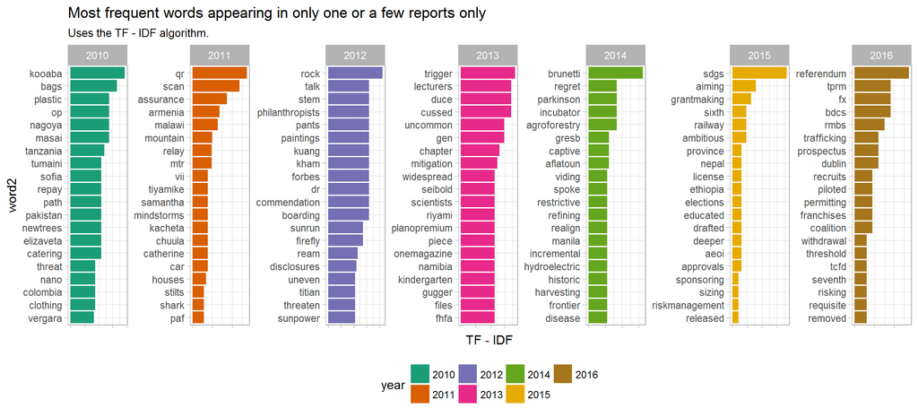

```r
ggplot(proportions_tdf, aes(x = word2, y = tf_idf, fill = year)) +
    geom_col() +
    scale_y_continuous("TF - IDF", labels = NULL) +
    scale_fill_manual(values = brewer.pal(7, "Dark2")) +
    facet_wrap(~ year, ncol = 7, scales = "free") +
    coord_flip() +
    #labs(y = NULL, x = NULL) +
    theme_light() +
    theme(legend.position = "bottom") +
    ggtitle(label =   "Most frequent words appearing in only one or a few reports only",
          subtitle = "Uses the TF - IDF algorithm.")
```

## Bank Buzzword Bingo

Our test for acronyms is those words that have two or more consecutive letters in capitals.

```r
case_sense_words <- bind_rows(
  get_text_from_crr_pdf('2016', to_lower = FALSE),
  get_text_from_crr_pdf('2015', to_lower = FALSE),
  get_text_from_crr_pdf('2014', to_lower = FALSE),
  get_text_from_crr_pdf('2013', to_lower = FALSE),
  get_text_from_crr_pdf('2012', to_lower = FALSE),
  get_text_from_crr_pdf('2011', to_lower = FALSE),
  get_text_from_crr_pdf('2010', to_lower = FALSE))


acronyms <- case_sense_words %>%
  filter(str_detect(word, "[A-Z][A-Z]")) %>%
  count(word, sort = TRUE) %>%
  mutate(ranking = min_rank(desc(n))) %>%
  ungroup()
```

Let’s make a word cloud of these.

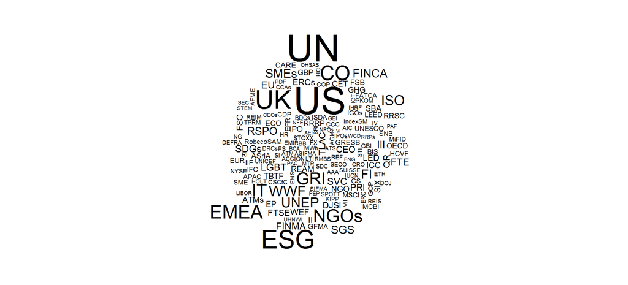

```r
acronyms %>%
  filter(!word %in% c("USD", "CHF", "AG")) %>%
  with(wordcloud(word, n, max.words = 400))
```

Plot the top top acronyms in each year.

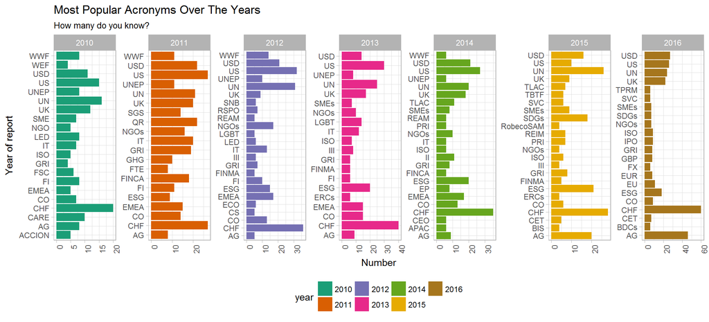

```r
case_sense_words %>%
  filter(str_detect(word, "[A-Z][A-Z]")) %>%
  count(year, word, sort = TRUE) %>%  # counting by year and word this time
  mutate(wordF = fct_reorder(word, n)) %>%
  #arrange(desc(n)) %>%
  top_n(20, n)  %>%
  ggplot(aes(x = word, y = n, fill = year)) +
  geom_bar(stat = "identity") +
  facet_wrap(~year, ncol = 7, scales = "free") +
  ggtitle("Most Popular Acronyms Over The Years",
          "How many do you know?") +
  scale_y_continuous("Number") +
  scale_x_discrete("Year of report") +
  #scale_fill_tableau(palette = "tableau10medium") +
  scale_fill_manual(values = year_colours) +
  coord_flip() +
  theme_light() +
  theme(legend.position = "bottom")  +
  theme(axis.text.x = element_text(angle = 90, hjust = 1)) # year labels rotated to fit
```